# WHAT MAKES A GREAT JAMES BOND MOVIE?

Kacper Dobek

2022-08-08

## Introduction

> Whether this is a great number or peculiar gadgets or glasses of cold vodka Martni, there are definitely many aspects constituting a great James Bond movie. Having watched *A spy who loved me (1977)* recently I’ve begun to wonder if that could be somehow assessed by the help of machine learning. This is my small summer data science project that aims to predict the average IMDB score for the newest 007 movie *No time to die* and see what contributes to the score.

> More formally, we will be looking at a regression problem for a small dataset (24 items) and training a random forest using cross validation. Then we will examine the breakdown plot for a previously unseen example - the new movie. I will be using *caret* package for the model and *DALEX* for explanation.

## 1. The data: For your eyes only

```r
data(JamesBond)
df <- JamesBond %>% select(-US_Gross, -World_Gross, -US_Adj, -Budget, -Avg_User_Rtn_Tom) %>%
  relocate(Avg_User_IMDB, .after = last_col())
```

I will be using the James Bond dataset from the HoRM package. See resources  
Here we have the data of the previous 24 movies. I’m going to use 12 ouf of the 18 available features, namely: Year, Movie, Bond, World_Adj, Budget_Adj, Film_Length, Conquests, Martinis, BJB, Kills_Bond, Kills_Others, Top_100, Avg_User_IMDB.  
To clear out the feature names:  
- **World_Adj** The film’s 2013-adjusted worldwide gross (in 1000’s of U.S. dollars).  
- **Budget_Adj** The film’s 2013-adjusted budget (in 1000’s of U.S. dollars).  
- **Avg_User_IMDB** The average user rating on IMDB (www.imdb.com).  
- **Conquests** The number of “conquests” by Bond in the film.  
- **Martinis** The number of martinis Bond drank in the film.  
- **BJB** The number of times Bond stated “Bond. James Bond.” in the movie.  
- **Kills_Bond** The number of people killed by Bond.  
- **Kills_Others** The number of people killed in the film by people other than Bond.  
- **Top_100** An indicator where a value of 1 means the title song within the top 100 on the UK Singles Chart and the U.S. Billboard Hot 100 and a value of 0 means it did not.

```r
kable(df)
```

| Year | Movie | Bond | World_Adj | Budget_Adj | Film_Length | Conquests | Martinis | BJB | Kills_Bond | Kills_Others | Top_100 | Avg_User_IMDB |
| --- | --- | --- | --- | --- | --- | --- | --- | --- | --- | --- | --- | --- |
| 1962 | Dr. No | Sean Connery | 457928 | 7688 | 110 | 3 | 2 | 1 | 4 | 8 | 0 | 7.3 |
| 1963 | From Russia with Love | Sean Connery | 598624 | 15174 | 115 | 4 | 0 | 0 | 11 | 16 | 0 | 7.5 |
| 1964 | Goldfinger | Sean Connery | 935404 | 22468 | 110 | 2 | 1 | 2 | 9 | 68 | 1 | 7.8 |
| 1965 | Thunderball | Sean Connery | 1040693 | 66333 | 130 | 3 | 0 | 0 | 20 | 90 | 1 | 7.0 |
| 1967 | You Only Live Twice | Sean Connery | 775740 | 66035 | 117 | 3 | 1 | 0 | 21 | 175 | 1 | 6.9 |
| 1969 | On Her Majesty’s Secret Service | George Lazenby | 518736 | 50608 | 142 | 3 | 1 | 2 | 5 | 37 | 0 | 6.8 |
| 1971 | Diamonds Are Forever | Sean Connery | 664969 | 41274 | 120 | 1 | 0 | 1 | 7 | 42 | 1 | 6.7 |
| 1973 | Live and Let Die | Roger Moore | 846046 | 36603 | 121 | 3 | 0 | 1 | 8 | 5 | 1 | 6.8 |
| 1974 | The Man with the Golden Gun | Roger Moore | 459623 | 32965 | 125 | 2 | 0 | 2 | 1 | 5 | 0 | 6.7 |
| 1977 | The Spy Who Loved Me | Roger Moore | 710290 | 53636 | 125 | 3 | 1 | 1 | 31 | 116 | 1 | 7.1 |
| 1979 | Moonraker | Roger Moore | 672514 | 99134 | 126 | 3 | 1 | 1 | 12 | 69 | 0 | 6.2 |
| 1981 | For Your Eyes Only | Roger Moore | 498812 | 71514 | 127 | 2 | 0 | 2 | 18 | 36 | 1 | 6.8 |
| 1983 | Octopussy | Roger Moore | 437059 | 64102 | 131 | 2 | 0 | 1 | 15 | 43 | 1 | 6.5 |
| 1985 | A View to a Kill | Roger Moore | 329322 | 64730 | 131 | 4 | 0 | 2 | 5 | 57 | 1 | 6.2 |
| 1987 | The Living Daylights | Timothy Dalton | 390758 | 81749 | 130 | 2 | 2 | 1 | 13 | 29 | 0 | 6.7 |
| 1989 | License to Kill | Timothy Dalton | 292392 | 78637 | 133 | 2 | 1 | 1 | 10 | 13 | 0 | 6.5 |
| 1995 | Goldeneye | Pierce Brosnan | 542985 | 91404 | 130 | 2 | 1 | 1 | 47 | 25 | 0 | 7.2 |
| 1997 | Tomorrow Never Dies | Pierce Brosnan | 491098 | 159117 | 119 | 3 | 1 | 1 | 30 | 24 | 0 | 6.4 |
| 1999 | The World Is Not Enough | Pierce Brosnan | 504091 | 188130 | 128 | 3 | 1 | 2 | 27 | 43 | 0 | 6.3 |
| 2002 | Die Another Day | Pierce Brosnan | 557433 | 183255 | 133 | 2 | 2 | 1 | 31 | 20 | 1 | 6.0 |
| 2006 | Casino Royale | Daniel Craig | 686784 | 117465 | 144 | 2 | 3 | 1 | 11 | 11 | 1 | 7.9 |
| 2008 | Quantum of Solace | Daniel Craig | 638035 | 248014 | 106 | 1 | 6 | 0 | 16 | 15 | 1 | 6.7 |
| 2012 | Skyfall | Daniel Craig | 1120980 | 202240 | 143 | 3 | 1 | 1 | 26 | 26 | 1 | 7.8 |
| 2015 | Spectre | Daniel Craig | 864553 | 240803 | 148 | 3 | 1 | 1 | 30 | 205 | 1 | 6.8 |

## 2. Stats: Live and let die

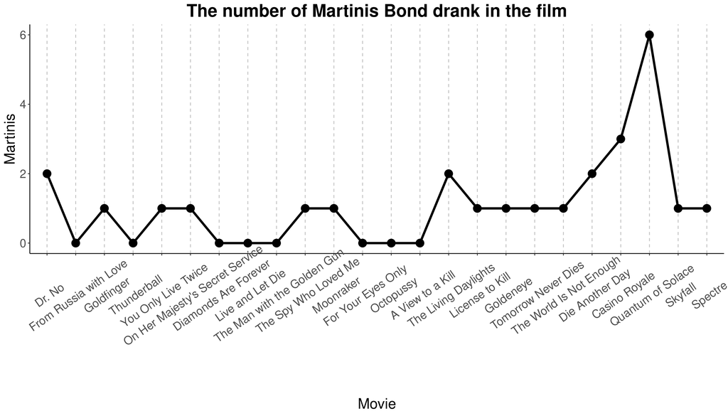

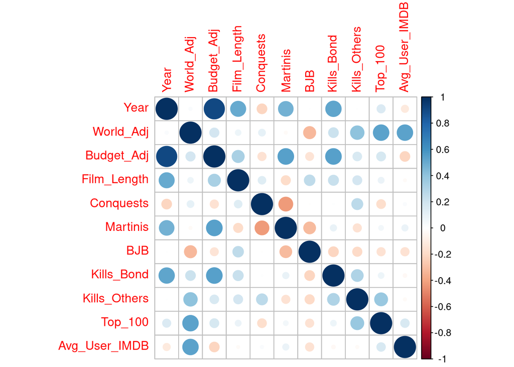

```r
df %>% select(-Movie, -Bond,) %>%
  cor() %>%
  corrplot()
```

```r
data(JamesBond)
df <- JamesBond %>% select(-Movie, -US_Gross, -World_Gross, -US_Adj, -Budget, -Avg_User_Rtn_Tom) %>%
  relocate(Avg_User_IMDB, .after = last_col())

train_control <- trainControl(method = "cv", number = 8, savePredictions = "all")

model_rf <- train(Avg_User_IMDB~. , data = df, method = "rf", ntree = 100, trControl = train_control)

explainer_rf <- DALEX::explain(model = model_rf,
                              label = "rf",
                              verbose = FALSE,
                              y = df$Avg_User_IMDB
                              )

print(model_performance(explainer_rf))
```

```
## Measures for:  regression
## mse        : 0.05157403
## rmse       : 0.2270992
## r2         : 0.7990078
## mad        : 0.1360167
##
## Residuals:
##          0%         10%         20%         30%         40%         50%
## -0.38593333 -0.30377500 -0.19552000 -0.12311000 -0.07096667 -0.03891667
##         60%         70%         80%         90%        100%
## -0.01014000  0.07145333  0.13466333  0.31706333  0.49035000
```

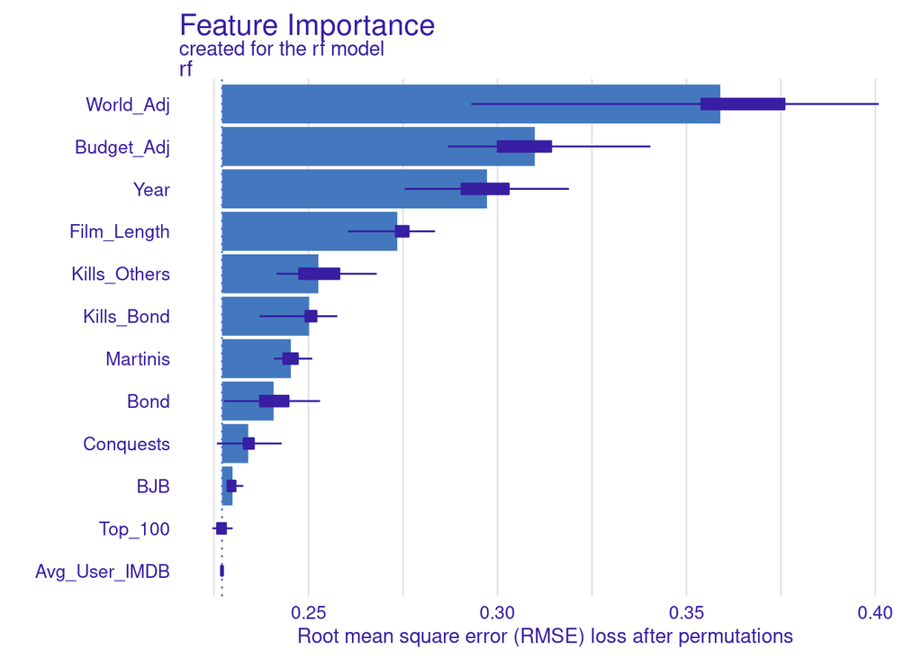

```r
plot(model_parts(explainer_rf, loss_function = loss_root_mean_square))
```

```r
no_time_to_die <- data.frame(2021, "Daniel Craig", 608510000, 214930000, 163, 0, 1, 1, 66, 109, 1, 0)
colnames(no_time_to_die) <- colnames(df)
df <- rbind(df, no_time_to_die)

kable(no_time_to_die)
```

| Year | Bond | World_Adj | Budget_Adj | Film_Length | Conquests | Martinis | BJB | Kills_Bond | Kills_Others | Top_100 | Avg_User_IMDB |
| --- | --- | --- | --- | --- | --- | --- | --- | --- | --- | --- | --- |
| 2021 | Daniel Craig | 608510000 | 214930000 | 163 | 0 | 1 | 1 | 66 | 109 | 1 | 0 |

```r
predict(explainer_rf, tail(df, n=1))
```

```
##       25
## 7.347983
```

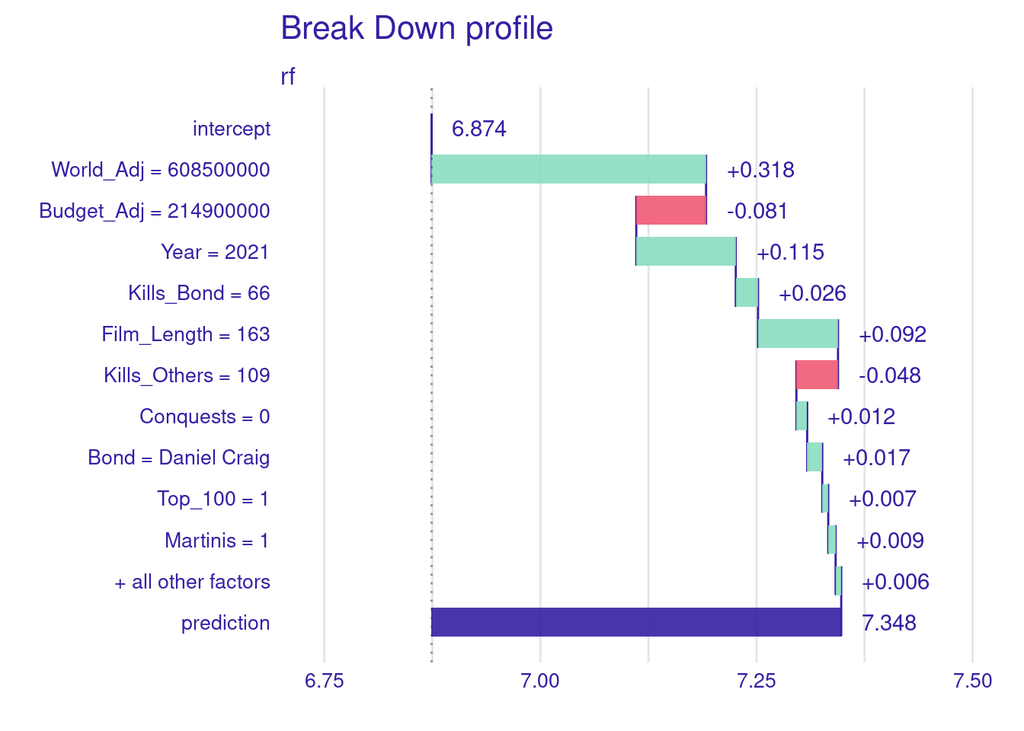

```r
pb = predict_parts(explainer = explainer_rf, tail(df, n=1), type= "break_down")
plot(pb)
```

## Resources

James Bond R dataset https://search.r-project.org/CRAN/refmans/HoRM/html/JamesBond.html

Daniel Craig’s retrospective https://youtu.be/2oZdJrph3RA